# Enfoque estadístico del aprendizaje: Trabajo Práctico nº 1

Análisis de un conjunto de datos de Properati

Santiago Rovere (srovere@gmail.com), Facultad de Ingeniería, Universidad de Buenos Aires

29 de septiembre de 2019

# Lectura de datos

```r
# Borrar variables del ambiente
rm(list = objects())

# Carga de paquetes necesarios para hacer los gráficos
require(Cairo)
require(GGally)
require(knitr)
require(prettydoc)
require(tidyverse)

# Uso de Cairo para renderizar los gráficos
options(bitmapType = "cairo")

# Cargar conjunto de datos
datos <- readr::read_csv(file = "ar_properties.csv")

# Mostrar estructura
head(datos)
```

```
## # A tibble: 6 x 24
##   id    ad_type start_date end_date   created_on   lat   lon l1    l2
##   <chr> <chr>   <date>     <date>     <date>     <dbl> <dbl> <chr> <chr>
## 1 S0we… Propie… 2019-04-14 2019-06-14 2019-04-14 -34.9 -54.9 Urug… Mald…
## 2 kMxc… Propie… 2019-04-14 2019-04-16 2019-04-14 -34.6 -58.4 Arge… Capi…
## 3 Ce3o… Propie… 2019-04-14 9999-12-31 2019-04-14  NA    NA   Arge… Bs.A…
## 4 AUGp… Propie… 2019-04-14 9999-12-31 2019-04-14 -34.7 -58.8 Arge… Bs.A…
## 5 m+Mw… Propie… 2019-04-14 2019-07-09 2019-04-14 -34.7 -58.8 Arge… Bs.A…
## 6 pJRP… Propie… 2019-04-14 2019-08-08 2019-04-14 -32.9 -60.7 Arge… Sant…
## # … with 15 more variables: l3 <chr>, l4 <chr>, l5 <chr>, l6 <lgl>,
## #   rooms <dbl>, bedrooms <dbl>, bathrooms <dbl>, surface_total <dbl>,
## #   surface_covered <dbl>, price <dbl>, currency <chr>,
## #   price_period <chr>, title <chr>, property_type <chr>,
## #   operation_type <chr>
```

Ahora nos quedamos con los datos pedidos

```r
datos.seleccionados <- datos %>%
  dplyr::filter(
    # propiedades de Capital Federal / Argentina
    (l1 == "Argentina" & l2 == "Capital Federal") &
    # cuyo precio está en dólares
    (currency == "USD") &
     # cuyo tipo sea Departamento, PH o Casa
    (property_type %in% c("Departamento", "PH", "Casa")) &
    # y que sean publicadas para Venta
    (operation_type == "Venta")
  ) %>%
  dplyr::select(id, l3, rooms, bedrooms, bathrooms, surface_total,
                surface_covered, price, property_type)
```

# Análisis exploratorio (I)

Obtenemos la cantidad de valores únicos y de faltantes para cada variable.

```r
resumen.cantidad <- purrr::map_dfr(
  .x = colnames(datos.seleccionados),
  .f = function(variable) {
    # Seleccionamos los datos para una variable
    valores.variable <- datos.seleccionados %>%
      dplyr::pull(!! variable)

    # Calculamos la cantidad de valores únicos y de valores faltantes
    return (
      data.frame(
        variable = variable,
        cantidad_unicos = length(unique(valores.variable)),
        cantidad_faltantes = length(which(is.na(valores.variable))),
        stringsAsFactors = FALSE
      )
    )
  }
)

# Mostramos una tabla con los valores calculados
knitr::kable(
  x = resumen.cantidad,
  col.names = c("Variable", "Cantidad de valores únicos",
                "Cantidad de valores faltantes"),
  align = c("l", "r", "r")
)
```

| Variable | Cantidad de valores únicos | Cantidad de valores faltantes |
| --- | --- | --- |
| id | 61905 | 0 |
| l3 | 58 | 355 |
| rooms | 24 | 5314 |
| bedrooms | 25 | 25298 |
| bathrooms | 15 | 3196 |
| surface_total | 671 | 3671 |
| surface_covered | 573 | 2975 |
| price | 4095 | 0 |
| property_type | 3 | 0 |

Obtenemos la matriz de correlación para las variables numéricas

```r
# Primero buscamos las variables numéricas
variables.numericas <- purrr::map(
  .x = colnames(datos.seleccionados),
  .f = function(variable) {
    return (ifelse(is.numeric(datos.seleccionados[[variable]]), variable, NA))
  }
) %>% purrr::keep(
  .x = .,
  .p = ~ ! is.na(.x)
) %>% unlist()

# Ahora seleccionamos esas variable y calculamos la matriz de correlación
datos.seleccionados.variables.numericas <- datos.seleccionados %>%
  dplyr::select(dplyr::one_of(variables.numericas))
matriz.correlacion <- stats::cor(datos.seleccionados.variables.numericas,
                                 use = "complete.obs")

# Mostramos una tabla considerando 3 dígitos decimales
knitr::kable(
  x = matriz.correlacion,
  digits = 3
)
```

|  | rooms | bedrooms | bathrooms | surface_total | surface_covered | price |
| --- | --- | --- | --- | --- | --- | --- |
| rooms | 1.000 | 0.921 | 0.613 | 0.068 | 0.075 | 0.487 |
| bedrooms | 0.921 | 1.000 | 0.616 | 0.067 | 0.072 | 0.432 |
| bathrooms | 0.613 | 0.616 | 1.000 | 0.062 | 0.068 | 0.599 |
| surface_total | 0.068 | 0.067 | 0.062 | 1.000 | 0.697 | 0.051 |
| surface_covered | 0.075 | 0.072 | 0.068 | 0.697 | 1.000 | 0.063 |
| price | 0.487 | 0.432 | 0.599 | 0.051 | 0.063 | 1.000 |

# Preparación de datos

Dado que la variable **bedrooms** contiene una alta proporción de valores faltantes y está altamente correlacionada con la variable **rooms**, entonces la eliminamos. Posteriormente, también eliminamos todas las observaciones que contengan algún dato faltantes.

```r
datos.sin.faltantes <- datos.seleccionados %>%
  # ELimino el atributo bedrooms
  dplyr::select(-bedrooms) %>%
  # Calculo la cantidad de faltantes para cada observación
  dplyr::mutate(
    faltantes = purrr::pmap(
      .l = .,
      .f = function(...) {
        # Devuelvo la cantidad de columnas que tienen atributo faltante
        columnas <- list(...)
        return (length(which(is.na(columnas))))
      }
    ) %>% unlist()
  ) %>%
  # Me quedo con las observaciones sin faltantes
  dplyr::filter(faltantes == 0) %>%
  # Elimino el atributo "faltantes"
  dplyr::select(-faltantes)

# Eliminamos bedrooms de las variables numéricas
variables.numericas <- variables.numericas[-which(variables.numericas == "bedrooms")]
```

# Analisis exploratorios (II)

Calculamos estadísticas descriptivas para la variable **precio** y realizamos un histograma de su distribución.

```r
# Realizamos una tabla con las estadísticas descriptivas
cuartiles.precio                 <- quantile(datos.sin.faltantes$price,
                                             probs = c(0.25, 0.5, 0.75))
estadisticas.descriptivas.precio <- datos.sin.faltantes %>%
  dplyr::summarise(
    Mínimo = min(price),
    Q1 = cuartiles.precio[1],
    Mediana = cuartiles.precio[2],
    Media = mean(price),
    Q3 = cuartiles.precio[3],
    Máximo = max(price)
  )

knitr::kable(
  x = estadisticas.descriptivas.precio,
  digits = 3
)
```

| Mínimo | Q1 | Mediana | Media | Q3 | Máximo |
| --- | --- | --- | --- | --- | --- |
| 6000 | 119000 | 170000 | 251577.2 | 270000 | 6e+06 |

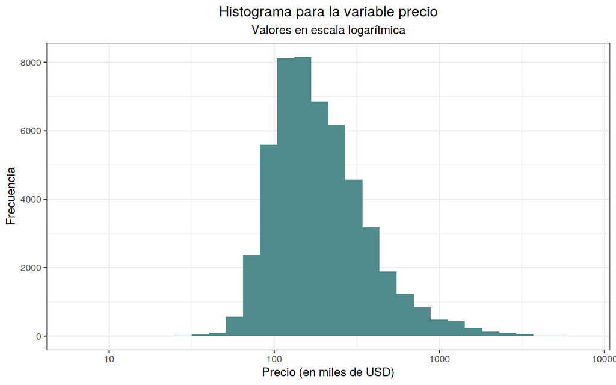

```r
# Y ahora el histograma
ggplot2::ggplot(data = datos.sin.faltantes) +
  ggplot2::geom_histogram(mapping = ggplot2::aes(x = price/1000),
                          fill = "darkslategray4") +
  ggplot2::scale_x_log10() +
  ggplot2::labs(x = "Precio (en miles de USD)", y = "Frecuencia",
                title = "Histograma para la variable precio",
                subtitle = "Valores en escala logarítmica") +
  ggplot2::theme_bw() +
  ggplot2::theme(
    plot.title = ggplot2::element_text(hjust = 0.5),
    plot.subtitle = ggplot2::element_text(hjust = 0.5),
  )
```

Ahora calculamos las estadísticas descriptivas agrupando por **property_type**.

```r
# Realizamos una tabla con las estadísticas descriptivas
estadisticas.descriptivas.precio.tipo.propiedad <- purrr::map_dfr(
  .x = unique(datos.sin.faltantes$property_type),
  .f = function(tipo_propiedad) {
    datos.tipo.propiedad                  <- datos.sin.faltantes %>%
      dplyr::filter(property_type == tipo_propiedad)
    cuartiles.precio.tipo                 <- quantile(datos.tipo.propiedad$price,
                                                      probs = c(0.25, 0.5, 0.75))
    estadisticas.descriptivas.precio.tipo <- datos.tipo.propiedad %>%
      dplyr::summarise(
        Tipo = tipo_propiedad,
        Mínimo = min(price),
        Q1 = cuartiles.precio.tipo[1],
        Mediana = cuartiles.precio.tipo[2],
        Media = mean(price),
        Q3 = cuartiles.precio.tipo[3],
        Máximo = max(price)
      )
  }
)

knitr::kable(
  x = estadisticas.descriptivas.precio.tipo.propiedad,
  digits = 3
)
```

| Tipo | Mínimo | Q1 | Mediana | Media | Q3 | Máximo |
| --- | --- | --- | --- | --- | --- | --- |
| Casa | 20000 | 235000 | 335000 | 434188.8 | 490000 | 5000000 |
| Departamento | 6000 | 115000 | 164000 | 246855.7 | 260000 | 6000000 |
| PH | 32000 | 137000 | 190000 | 218747.4 | 270000 | 1500000 |

Para cada tipo de propiedad, elaboramos un boxplot. Se observan una cantidad importante de propiedades con precios atípicos (outliers) para cada tipo de propiedad.

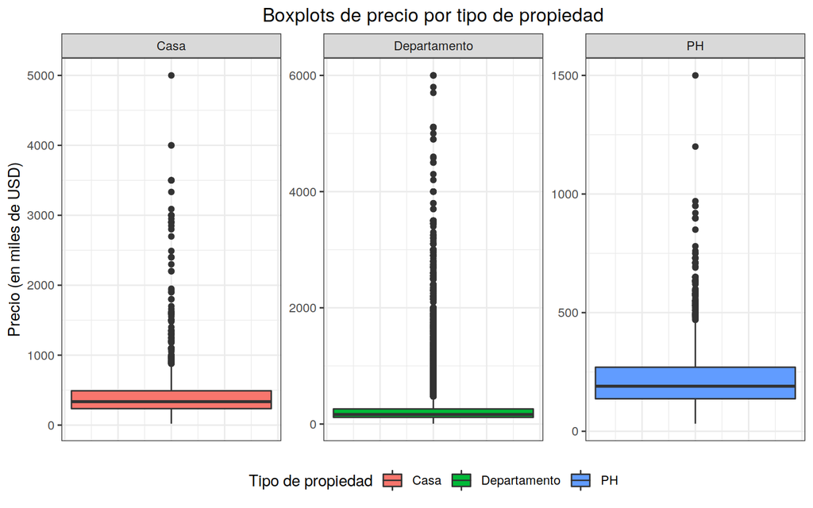

```r
ggplot2::ggplot(data = datos.sin.faltantes) +
  ggplot2::geom_boxplot(mapping = ggplot2::aes(y = price/1000, fill = property_type)) +
  ggplot2::facet_wrap(~ property_type, nrow = 1, scales = "free") +
  ggplot2::labs(y = "Precio (en miles de USD)",
                title = "Boxplots de precio por tipo de propiedad",
                fill = "Tipo de propiedad") +
  ggplot2::theme_bw() +
  ggplot2::theme(
    legend.position = "bottom",
    plot.title = ggplot2::element_text(hjust = 0.5),
    plot.subtitle = ggplot2::element_text(hjust = 0.5),
    axis.title.x = ggplot2::element_blank(),
    axis.text.x = ggplot2::element_blank(),
    axis.ticks.x = ggplot2::element_blank()
  )
```

Finalmente, realizamos un correlograma de las variables numéricas.

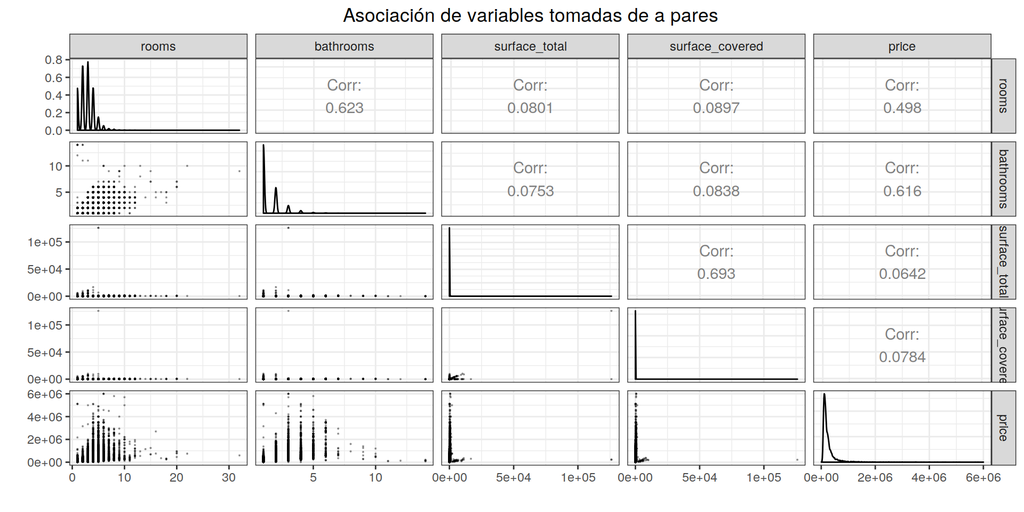

```r
datos.numericos <- datos.sin.faltantes %>%
  dplyr::select(dplyr::one_of(variables.numericas))

GGally::ggpairs(data = datos.numericos,
                #upper = list(continuous = wrap("density", alpha = 0.5), combo = "box"),
                lower = list(continuous = GGally::wrap("points", alpha = 0.3,    size=0.1),
                             combo = GGally::wrap("dot", alpha = 0.4,            size=0.2) )) +
  ggplot2::labs(title = "Asociación de variables tomadas de a pares", x = "", y = "") +
  ggplot2::theme_bw() +
  ggplot2::theme(
    legend.position = "bottom",
    plot.title = ggplot2::element_text(hjust = 0.5),
    plot.subtitle = ggplot2::element_text(hjust = 0.5)
  )
```

# Tratamiento de outliers

Se eliminan los outliers de la variable **precio**. El criterio de eliminación se basa en la remoción de valores menores a *Q1 - 1.5IRQ* y mayores a *Q3 + 1.5IQR* para cada tipo de propiedad.

```r
valores.corte <- estadisticas.descriptivas.precio.tipo.propiedad %>%
  dplyr::mutate(precio_inferior = Q1 - 1.5 * (Q3 - Q1),
                precio_superior = Q3 + 1.5 * (Q3 - Q1)) %>%
  dplyr::rename(property_type = Tipo) %>%
  dplyr::select(property_type, precio_inferior, precio_superior)

datos.sin.outliers <- datos.sin.faltantes %>%
  dplyr::inner_join(valores.corte, by = c("property_type")) %>%
  dplyr::filter(price > precio_inferior & price < precio_superior) %>%
  dplyr::select(-precio_inferior, -precio_superior)
```

# Analisis exploratorios (III)

Luego de baer eliminado los outliers de **precio**, volvemos a realizar los mismos análisis exploratorios. Calculamos estadísticas descriptivas para la variable **precio** y realizamos un histograma de su distribución.

```r
# Realizamos una tabla con las estadísticas descriptivas
cuartiles.precio                 <- quantile(datos.sin.outliers$price,
                                             probs = c(0.25, 0.5, 0.75))
estadisticas.descriptivas.precio <- datos.sin.outliers %>%
  dplyr::summarise(
    Mínimo = min(price),
    Q1 = cuartiles.precio[1],
    Mediana = cuartiles.precio[2],
    Media = mean(price),
    Q3 = cuartiles.precio[3],
    Máximo = max(price)
  )

knitr::kable(
  x = estadisticas.descriptivas.precio,
  digits = 3
)
```

| Mínimo | Q1 | Mediana | Media | Q3 | Máximo |
| --- | --- | --- | --- | --- | --- |
| 6000 | 115000 | 160000 | 188838.9 | 240000 | 870000 |

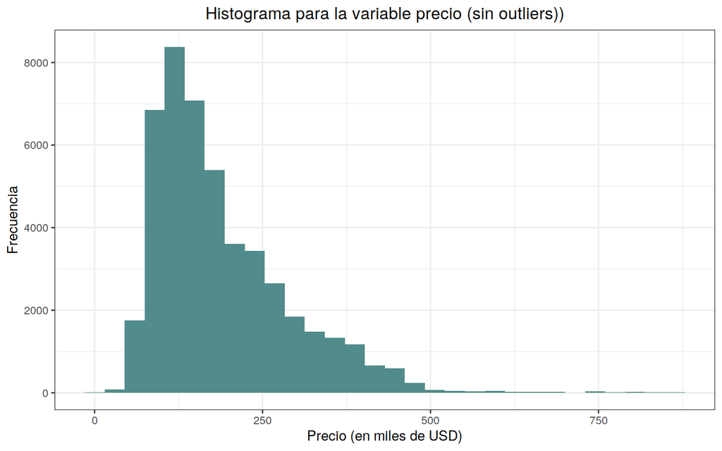

```r
# Y ahora el histograma
ggplot2::ggplot(data = datos.sin.outliers) +
  ggplot2::geom_histogram(mapping = ggplot2::aes(x = price/1000),
                          fill = "darkslategray4") +
  ggplot2::labs(x = "Precio (en miles de USD)", y = "Frecuencia",
                title = "Histograma para la variable precio (sin outliers))") +
  ggplot2::theme_bw() +
  ggplot2::theme(
    plot.title = ggplot2::element_text(hjust = 0.5),
    plot.subtitle = ggplot2::element_text(hjust = 0.5),
  )
```

Ahora calculamos las estadísticas descriptivas agrupando por **property_type**.

```r
# Realizamos una tabla con las estadísticas descriptivas
estadisticas.descriptivas.precio.tipo.propiedad <- purrr::map_dfr(
  .x = unique(datos.sin.outliers$property_type),
  .f = function(tipo_propiedad) {
    datos.tipo.propiedad                  <- datos.sin.outliers %>%
      dplyr::filter(property_type == tipo_propiedad)
    cuartiles.precio.tipo                 <- quantile(datos.tipo.propiedad$price,
                                                      probs = c(0.25, 0.5, 0.75))
    estadisticas.descriptivas.precio.tipo <- datos.tipo.propiedad %>%
      dplyr::summarise(
        Tipo = tipo_propiedad,
        Mínimo = min(price),
        Q1 = cuartiles.precio.tipo[1],
        Mediana = cuartiles.precio.tipo[2],
        Media = mean(price),
        Q3 = cuartiles.precio.tipo[3],
        Máximo = max(price)
      )
  }
)

knitr::kable(
  x = estadisticas.descriptivas.precio.tipo.propiedad,
  digits = 3
)
```

| Tipo | Mínimo | Q1 | Mediana | Media | Q3 | Máximo |
| --- | --- | --- | --- | --- | --- | --- |
| Casa | 20000 | 230000 | 320000 | 355662.3 | 450000 | 870000 |
| Departamento | 6000 | 110000 | 153900 | 178809.4 | 229000 | 477285 |
| PH | 32000 | 135000 | 189000 | 207077.6 | 269000 | 468000 |

Para cada tipo de propiedad, elaboramos un boxplot.

[figure not shown]

```r
ggplot2::ggplot(data = datos.sin.outliers) +
  ggplot2::geom_boxplot(mapping = ggplot2::aes(y = price/1000, fill = property_type)) +
  ggplot2::facet_wrap(~ property_type, nrow = 1, scales = "free") +
  ggplot2::labs(y = "Precio (en miles de USD)",
                title = "Boxplots de precio por tipo de propiedad",
                subtitle = "Valores en escala logarítmica",
                fill = "Tipo de propiedad") +
  ggplot2::theme_bw() +
  ggplot2::theme(
    legend.position = "bottom",
    plot.title = ggplot2::element_text(hjust = 0.5),
    plot.subtitle = ggplot2::element_text(hjust = 0.5),
    axis.title.x = ggplot2::element_blank(),
    axis.text.x = ggplot2::element_blank(),
    axis.ticks.x = ggplot2::element_blank()
  )
```

Finalmente, realizamos un correlograma de las variables numéricas.

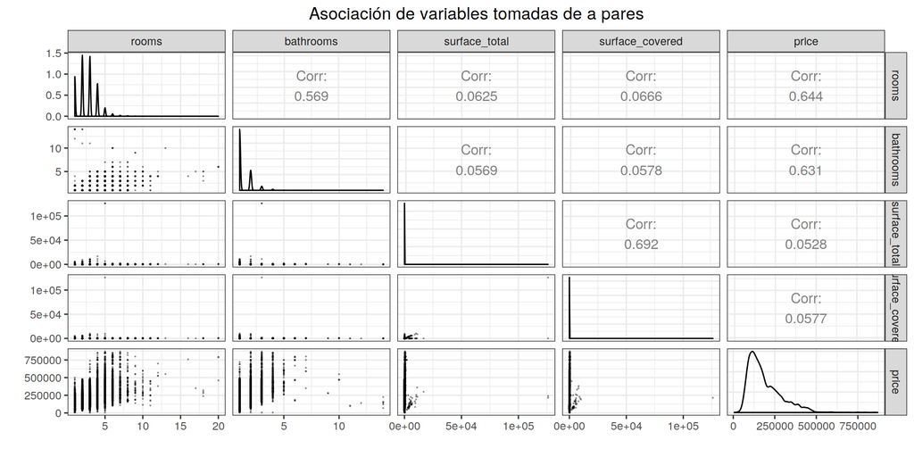

```r
datos.numericos <- datos.sin.outliers %>%
  dplyr::select(dplyr::one_of(variables.numericas))

GGally::ggpairs(data = datos.numericos,
                #upper = list(continuous = wrap("density", alpha = 0.5), combo = "box"),
                lower = list(continuous = GGally::wrap("points", alpha = 0.3,    size=0.1),
                             combo = GGally::wrap("dot", alpha = 0.4,            size=0.2) )) +
  ggplot2::labs(title = "Asociación de variables tomadas de a pares", x = "", y = "") +
  ggplot2::theme_bw() +
  ggplot2::theme(
    legend.position = "bottom",
    plot.title = ggplot2::element_text(hjust = 0.5),
    plot.subtitle = ggplot2::element_text(hjust = 0.5)
  )
```

# Modelo lineal

Efectuamos dos modelos lineales simples para predecir la variable **precio**. El primero, basado en la cantidad de habitaciones (*rooms*) y el segundo, en función de la superficie total (*surface_total*).

```r
modelo.habitaciones <- stats::lm(formula = price ~ rooms, data = datos.sin.outliers)
summary(modelo.habitaciones)
```

```
##
## Call:
## stats::lm(formula = price ~ rooms, data = datos.sin.outliers)
##
## Residuals:
##     Min      1Q  Median      3Q     Max
## -747427  -47389  -11167   31890  590776
##
## Coefficients:
##             Estimate Std. Error t value Pr(>|t|)
## (Intercept)  51451.2      834.4   61.67   <2e-16 ***
## rooms        51943.1      284.7  182.47   <2e-16 ***
## ---
## Signif. codes:  0 '***' 0.001 '**' 0.01 '*' 0.05 '.' 0.1 ' ' 1
##
## Residual standard error: 77900 on 46954 degrees of freedom
## Multiple R-squared:  0.4149, Adjusted R-squared:  0.4149
## F-statistic: 3.33e+04 on 1 and 46954 DF,  p-value: < 2.2e-16
```

```r
modelo.superficie <- stats::lm(formula = price ~ surface_total, data = datos.sin.outliers)
summary(modelo.superficie)
```

```
##
## Call:
## stats::lm(formula = price ~ surface_total, data = datos.sin.outliers)
##
## Residuals:
##     Min      1Q  Median      3Q     Max
## -772520  -73607  -28772   51196  679199
##
## Coefficients:
##                Estimate Std. Error t value Pr(>|t|)
## (Intercept)   1.883e+05  4.720e+02  398.85   <2e-16 ***
## surface_total 6.340e+00  5.531e-01   11.46   <2e-16 ***
## ---
## Signif. codes:  0 '***' 0.001 '**' 0.01 '*' 0.05 '.' 0.1 ' ' 1
##
## Residual standard error: 101700 on 46954 degrees of freedom
## Multiple R-squared:  0.002791,   Adjusted R-squared:  0.00277
## F-statistic: 131.4 on 1 and 46954 DF,  p-value: < 2.2e-16
```